# アテンション機構付きの seq2seq モデルで機械翻訳する（PyTorch チュートリアル）

参考文献の 1 つ目のチュートリアルをやります。コードの順序を前後させていたりデバッグプリントを入れていることがあります。自分の誤りは自分に帰属します。何か問題がありましたら以下からご連絡いただけますと幸いです。  
https://github.com/CookieBox26/ToyBox/issues

### 参考文献

- [NLP FROM SCRATCH: TRANSLATION WITH A SEQUENCE TO SEQUENCE NETWORK AND ATTENTION](https://pytorch.org/tutorials/intermediate/seq2seq_translation_tutorial.html)
  - 本記事でなぞるチュートリアル。seq2seq モデルでフランス語を英語に機械翻訳する。
- [[1409.3215] Sequence to Sequence Learning with Neural Networks](https://arxiv.org/abs/1409.3215)
  - チュートリアル中の随所の sequence to sequence network という文字列からリンクがある論文。この論文では英仏翻訳している。
- [フランス語の否定文 - Wikipedia](https://ja.wikipedia.org/wiki/%E3%83%95%E3%83%A9%E3%83%B3%E3%82%B9%E8%AA%9E%E3%81%AE%E5%90%A6%E5%AE%9A%E6%96%87)
  - 「ne ... pas に代表されるように否定が ne を含む 2 語で表される」（ことからも仏英翻訳は単語を単語に翻訳すればいいのではないことがわかる）。
- [[1406.1078] Learning Phrase Representations using RNN Encoder-Decoder for Statistical Machine Translation](https://arxiv.org/abs/1406.1078)
  - これもチュートリアル冒頭で2回繰り返し紹介されている論文。この論文で GRU が提案、導入された。
- [[1409.0473] Neural Machine Translation by Jointly Learning to Align and Translate](https://arxiv.org/abs/1409.0473)
  - これもチュートリアル冒頭で2回繰り返し紹介されている論文。

### 目次

- データの準備
- seq2seq モデル
- アテンションデコーダの導入
- モデルの訓練
- 訓練結果

## データの準備

[output not shown]

```python
print('◆ データの冒頭')
with open('./data/eng-fra.txt', mode='r') as ifile:
    for i, line in enumerate(ifile):
        if i == 10:
            break
        print(line.strip())
```

```
◆ データの冒頭
Go.	Va !
Run!	Cours !
Run!	Courez !
Wow!	Ça alors !
Fire!	Au feu !
Help!	À l'aide !
Jump.	Saute.
Stop!	Ça suffit !
Stop!	Stop !
Stop!	Arrête-toi !
```

[output not shown]

```python
import unicodedata
import re


# ユニコード文字集合をアスキー文字集合だけで表現する関数
# ここでは、元文字列の各文字を NFD という正規化形式で分解することで
# アクセント記号を分離し、アクセント記号は除去する
# 元コメント：
# Turn a Unicode string to plain ASCII, thanks to
# https://stackoverflow.com/a/518232/2809427
def unicodeToAscii(s):
    return ''.join(
        c for c in unicodedata.normalize('NFD', s)
        if unicodedata.category(c) != 'Mn'
    )


# 小文字化、アスキーコード化、句点と感嘆符と疑問符の切り離し、記号除去する関数
def normalizeString(s):
    s = unicodeToAscii(s.lower().strip())  # 小文字化、アスキーコード化
    s = re.sub(r"([.!?])", r" \1", s)  # 任意の文字に続く . !  ? の前に空白を挟む
    s = re.sub(r"[^a-zA-Z.!?]+", r" ", s)  # アルファベット . ! ? 以外は除去
    return s


print('◆ データの冒頭にプレ処理を適用')
with open('./data/eng-fra.txt', mode='r') as ifile:
    for i, line in enumerate(ifile):
        if i == 10:
            break
        pair = line.strip().split('\t')
        print('-'*30)
        print('オリジナル   ', pair[0], '\t', pair[1])
        print('ASCII文字化  ', unicodeToAscii(pair[0]), '\t', unicodeToAscii(pair[1]))
        print('記号トリム   ', normalizeString(pair[0]), '\t', normalizeString(pair[1]))
```

```
◆ データの冒頭にプレ処理を適用
------------------------------
オリジナル    Go. 	 Va !
ASCII文字化   Go. 	 Va !
記号トリム    go . 	 va !
------------------------------
オリジナル    Run! 	 Cours !
ASCII文字化   Run! 	 Cours !
記号トリム    run ! 	 cours !
------------------------------
オリジナル    Run! 	 Courez !
ASCII文字化   Run! 	 Courez !
記号トリム    run ! 	 courez !
------------------------------
オリジナル    Wow! 	 Ça alors !
ASCII文字化   Wow! 	 Ca alors !
記号トリム    wow ! 	 ca alors !
------------------------------
オリジナル    Fire! 	 Au feu !
ASCII文字化   Fire! 	 Au feu !
記号トリム    fire ! 	 au feu !
------------------------------
オリジナル    Help! 	 À l'aide !
ASCII文字化   Help! 	 A l'aide !
記号トリム    help ! 	 a l aide !
------------------------------
オリジナル    Jump. 	 Saute.
ASCII文字化   Jump. 	 Saute.
記号トリム    jump . 	 saute .
------------------------------
オリジナル    Stop! 	 Ça suffit !
ASCII文字化   Stop! 	 Ca suffit !
記号トリム    stop ! 	 ca suffit !
------------------------------
オリジナル    Stop! 	 Stop !
ASCII文字化   Stop! 	 Stop !
記号トリム    stop ! 	 stop !
------------------------------
オリジナル    Stop! 	 Arrête-toi !
ASCII文字化   Stop! 	 Arrete-toi !
記号トリム    stop ! 	 arrete toi !
```

|  | そして今回は簡単のために、全ての文章を学習するのではなく、「10単語未満」「特定のフレーズで始まる」文章に絞るようですね。 |
| --- | --- |

```python
# 今回は10単語未満の文章に絞る
MAX_LENGTH = 10

# 今回は英文側が以下のフレーズで始まる文章に絞る
eng_prefixes = (
    "i am ", "i m ",
    "he is", "he s ",
    "she is", "she s ",
    "you are", "you re ",
    "we are", "we re ",
    "they are", "they re "
)


def filterPair(p):
    return len(p[0].split(' ')) < MAX_LENGTH and \
        len(p[1].split(' ')) < MAX_LENGTH and \
        p[1].startswith(eng_prefixes)


# 文章ペアのリストをフィルタする関数
def filterPairs(pairs):
    return [pair for pair in pairs if filterPair(pair)]
```

|  | ここまでで用意した関数を利用してデータを生成する処理が以下ですね。まずすべての文章ペアをロードし、対象の文章ペアに絞り込んだ上で、全ての単語の頻度をカウントしながらインデックスをふっています。 |
| --- | --- |

```python
SOS_token = 0
EOS_token = 1


# ある語の語彙を管理するクラス
# 文章を流し込んでいくことで単語にインデックスをふり各単語の頻度もカウントする
class Lang:
    def __init__(self, name):
        self.name = name
        self.word2index = {}
        self.word2count = {}
        self.index2word = {0: "SOS", 1: "EOS"}
        self.n_words = 2  # Count SOS and EOS

    def addSentence(self, sentence):
        for word in sentence.split(' '):
            self.addWord(word)

    def addWord(self, word):
        if word not in self.word2index:
            self.word2index[word] = self.n_words
            self.word2count[word] = 1
            self.index2word[self.n_words] = word
            self.n_words += 1
        else:
            self.word2count[word] += 1


# X語 Y語 のタグ区切り文章ペアがあるファイルから文章を正規化しながら読み取り、
# 文章ペアのリストを取り出す関数
# 順序を Y語 X語 に入れ替えて取り出すこともできる
def readLangs(lang1, lang2, reverse=False):
    lines = open('./data/%s-%s.txt' % (lang1, lang2), encoding='utf-8').\
        read().strip().split('\n')
    pairs = [[normalizeString(s) for s in l.split('\t')] for l in lines]

    if reverse:
        pairs = [list(reversed(p)) for p in pairs]
        input_lang = Lang(lang2)
        output_lang = Lang(lang1)
    else:
        input_lang = Lang(lang1)
        output_lang = Lang(lang2)

    return input_lang, output_lang, pairs


# ファイルから文章を読み込み、対象の文章にフィルタし、語彙を作成
def prepareData(lang1, lang2, reverse=False):
    input_lang, output_lang, pairs = readLangs(lang1, lang2, reverse)  # ファイルから文章取得
    print("%s ペアを読み込みました" % len(pairs))
    pairs = filterPairs(pairs)  # 10単語未満で特定のフレーズから始まる文章に絞り込み
    print("%s ペアに絞り込みました" % len(pairs))
    # 語彙作成
    for pair in pairs:
        input_lang.addSentence(pair[0])
        output_lang.addSentence(pair[1])
    print("単語数は以下でした")
    print(input_lang.name, input_lang.n_words)
    print(output_lang.name, output_lang.n_words)
    return input_lang, output_lang, pairs


input_lang, output_lang, pairs = prepareData('eng', 'fra', True)
```

```
135842 ペアを読み込みました
10599 ペアに絞り込みました
単語数は以下でした
fra 4345
eng 2803
```

```python
print('◆ データの冒頭')
for i, pair in enumerate(pairs):
    if i == 10:
        break
    print(pair)
```

```
◆ データの冒頭
['j ai ans .', 'i m .']
['je vais bien .', 'i m ok .']
['ca va .', 'i m ok .']
['je suis gras .', 'i m fat .']
['je suis gros .', 'i m fat .']
['je suis en forme .', 'i m fit .']
['je suis touche !', 'i m hit !']
['je suis touchee !', 'i m hit !']
['je suis malade .', 'i m ill .']
['je suis triste .', 'i m sad .']
```

|  | データが用意できましたが、これは単に文章のペアたちですから PyTorch の機械学習モデルに入れることはできませんね。単語に split して各単語をインデックスに直して PyTorch のテンソルにする必要があります。そのための関数を先に用意しておきましょう。文末には文末トークンを付けるようですね。 |
| --- | --- |

```python
import torch


def indexesFromSentence(lang, sentence):
    return [lang.word2index[word] for word in sentence.split(' ')]


def tensorFromSentence(lang, sentence):
    indexes = indexesFromSentence(lang, sentence)
    indexes.append(EOS_token)
    return torch.tensor(indexes, dtype=torch.long, device='cpu').view(-1, 1)


def tensorsFromPair(pair):
    input_tensor = tensorFromSentence(input_lang, pair[0])
    target_tensor = tensorFromSentence(output_lang, pair[1])
    return (input_tensor, target_tensor)


print('◆ 生データ')
print(pairs[0])
(input_tensor, target_tensor) = tensorsFromPair(pairs[0])
print('\n◆ インプットデータ')
print(input_tensor.size())
print(input_tensor)
print('\n◆ ターゲットデータ')
print(target_tensor.size())
print(target_tensor)
```

```
◆ 生データ
['j ai ans .', 'i m .']

◆ インプットデータ
torch.Size([5, 1])
tensor([[2],
        [3],
        [4],
        [5],
        [1]])

◆ ターゲットデータ
torch.Size([4, 1])
tensor([[2],
        [3],
        [4],
        [1]])
```

## seq2seq モデル

[figure not shown]

肝心のモデルの話に入っていきますね。ここでは seq2seq モデルといって、エンコーダの RNN とデコーダの RNN をもつモデルを採用するのでしょうか。エンコーダが入力された文章を1つの特徴ベクトル（コンテクストベクトル）に変換し、デコーダがそれを出力文章に変換するようです。エンコードした特徴の空間の1点1点が入力された文章の「意味」なのだというようにもありますね。…というかこのようなモデルを seq2seq モデルというのですね。てっきり入力も出力もシーケンスなら何でも seq2seq モデルとよぶのかと。

[figure not shown]

チュートリアルが Sequence to Sequence network からリンクしているのは以下の論文だね。

- [[1409.3215] Sequence to Sequence Learning with Neural Networks](https://arxiv.org/abs/1409.3215)

2014年の論文で、シーケンスをシーケンスにマッピングする汎用的なアプローチを提案すると。具体的には、入力シーケンスを多層LSTMで特徴ベクトルにエンコードし、それをまた別の多層LSTMで出力シーケンスにデコードするみたい。

[figure not shown]

はあ。その seq2seq モデルの方が RNN より機械翻訳に適しているとありますね。翻訳は単語を受け取る度に単語を出すという類のものではないからです。フランス語と英語では chat noir と black cat のように形容詞の位置も違いますし、それにフランス語には ne/pas 構造もありますし…ne/pas 構造とは？

[figure not shown]

フランス語の否定文は、多くの言語と違って、動詞を ne と pas で挟むみたいだね。

- [フランス語の否定文 - Wikipedia](https://ja.wikipedia.org/wiki/%E3%83%95%E3%83%A9%E3%83%B3%E3%82%B9%E8%AA%9E%E3%81%AE%E5%90%A6%E5%AE%9A%E6%96%87)

だから必然的に単語数自体がずれる。先の前置修飾と後置修飾の違いもあるし、特に英仏翻訳では seq2seq モデルが適しているのかもしれない。

[figure not shown]

ええ…フランス語は否定文の形式が変わっているんですね…しかしその記事の言語学的なサイクルは理解できるような。当初は動詞の前に否定表現を付けて、強調のために動詞の後にも否定表現を付けて、やがて後者のみが残るという。まあそれで、そのように翻訳というのはまず入力文を全て読み取った後出力文にするのがよいので、エンコーダとデコーダを構築するわけですが、エンコーダとデコーダに含まれている GRU なる層は何でしょう？

[figure not shown]

チュートリアル冒頭で紹介があった以下の論文で導入されていて、LSTMより少しシンプルになっている再帰ニューラルネットワークだね。LSTM よりも自由度は少ないけどタスクの種類やデータサイズによってはLSTMと同等かそれ以上の性能が見込めるみたい。

- [[1406.1078] Learning Phrase Representations using RNN Encoder-Decoder for Statistical Machine Translation](https://arxiv.org/abs/1406.1078)

もっとも、torch.nn.GRU は Fully Gated Unit なんだけど arxiv:1406.1078 の定式化とは少し違っている。後の論文で改良されたとかかな？ 参考文献がなかったからわからないや。

- https://pytorch.org/docs/master/generated/torch.nn.GRU.html

[figure not shown]

シンプルにしたLSTM？ いや確かに LSTM よりすっきりしていますが、記憶セル c がないんですね。むしろ出力 h とされているものが記憶セルに近そうな…。

#### vanilla RNN と LSTM

[figure not shown]

#### GRU

[figure not shown]

#### torch.nn.GRU

[figure not shown]

|  | …まあそれで、エンコーダとデコーダは具体的には以下のコードですね。単語インデックスを高次元に埋め込んで GRU するだけです。エンコード時は特徴をどんどん積み重ねていき、デコード時は特徴をどんどん紐解いていくとイメージすればよいのでしょうか。コードの下に図も描いておきました。 |
| --- | --- |

```python
import torch.nn as nn
from torch import optim
import torch.nn.functional as F

class EncoderRNN(nn.Module):
    def __init__(self, input_size, hidden_size):
        super(EncoderRNN, self).__init__()
        self.hidden_size = hidden_size
        self.embedding = nn.Embedding(input_size, hidden_size)
        self.gru = nn.GRU(hidden_size, hidden_size)

    def forward(self, input, hidden, debug=False):
        if debug:
            print('入力単語： ', input.size(), input)
            print('入力特徴： ', hidden.size(), hidden[:,:,:3])
        embedded = self.embedding(input).view(1, 1, -1)
        if debug:
            print('埋め込み後　 ： ', embedded.size(), embedded[:,:,:3])
        output = embedded
        output, hidden = self.gru(output, hidden)
        if debug:
            print('GRUの出力　　： ', output.size(), output[:,:,:3])
            print('GRUの隠れ状態： ', hidden.size(), hidden[:,:,:3])
            print('（単語を1つずつ流しているので出力と隠れ状態は一致）')
        return output, hidden

    def initHidden(self):
        return torch.zeros(1, 1, self.hidden_size, device='cpu')

class DecoderRNN(nn.Module):
    def __init__(self, hidden_size, output_size):
        super(DecoderRNN, self).__init__()
        self.hidden_size = hidden_size

        self.embedding = nn.Embedding(output_size, hidden_size)
        self.gru = nn.GRU(hidden_size, hidden_size)
        self.out = nn.Linear(hidden_size, output_size)
        self.softmax = nn.LogSoftmax(dim=1)

    def forward(self, input, hidden, debug=False):
        if debug:
            print('入力単語： ', input.size(), input)
            print('入力特徴： ', hidden.size(), hidden[:,:,:3])
        output = self.embedding(input).view(1, 1, -1)
        output = F.relu(output)
        output, hidden = self.gru(output, hidden)
        if debug:
            print('GRUの出力　　： ', output.size(), output[:,:,:3])
            print('GRUの隠れ状態： ', hidden.size(), hidden[:,:,:3])
            print('（単語を1つずつ流しているので出力と隠れ状態は一致）')
        output = self.softmax(self.out(output[0]))
        if debug:
            print('最終出力 　　： ', output.size(), output[:,:3])
        return output, hidden

    def initHidden(self):
        return torch.zeros(1, 1, self.hidden_size, device='cpu')

hidden_size = 256
encoder = EncoderRNN(input_lang.n_words, hidden_size).to('cpu')
decoder = DecoderRNN(hidden_size, output_lang.n_words).to('cpu')

print('◆ エンコーダの訓練対象パラメータ')
for name, param in encoder.named_parameters():
    print(name.ljust(14), param.size())

print('\n◆ デコーダの訓練対象パラメータ')
for name, param in decoder.named_parameters():
    print(name.ljust(14), param.size())
```

```
◆ エンコーダの訓練対象パラメータ
embedding.weight torch.Size([4345, 256])
gru.weight_ih_l0 torch.Size([768, 256])
gru.weight_hh_l0 torch.Size([768, 256])
gru.bias_ih_l0 torch.Size([768])
gru.bias_hh_l0 torch.Size([768])

◆ デコーダの訓練対象パラメータ
embedding.weight torch.Size([2803, 256])
gru.weight_ih_l0 torch.Size([768, 256])
gru.weight_hh_l0 torch.Size([768, 256])
gru.bias_ih_l0 torch.Size([768])
gru.bias_hh_l0 torch.Size([768])
out.weight     torch.Size([2803, 256])
out.bias       torch.Size([2803])
```

#### エンコーダとデコーダ

[figure not shown]

|  | 仏英翻訳だから、エンコーダにはフランス語の文章を1単語ずつ入れていくことになるね。1単語入れる度にエンコーダから特徴が出力される。1つの文章を入れ終わった最終的な特徴がコンテクストベクトルだね。コンテクストが得られたら、デコーダに文頭トークンとコンテクストベクトルを入れることで1語ずつ単語を取り出す。文末トークンが出てきたらデコードは終了って感じなのかな。 |
| --- | --- |

#### 翻訳の流れ

[figure not shown]

|  | 実際に翻訳をシミュレーションしてみましょう。無論、まだエンコーダもデコーダも学習していませんので、エンコードとデコードはでたらめです。その状態でデコーダが文末トークンを出すまでデコードを続けることはできませんので、デコーダから3単語まで取り出してみましょう。 |
| --- | --- |

```python
print('◆ エンコーダに1つ目のデータを流してみる')
input_words = pairs[0][0].split(' ') + ['<EOS>']
(input_tensor, target_tensor) = tensorsFromPair(pairs[0])
print('\n◇ インプットデータ')
print(input_words)
print(input_tensor)
input_length = input_tensor.size(0)
hidden = encoder.initHidden()
for ei in range(input_length):
    print('\n◇ 流す単語： ' + input_words[ei])
    output, hidden = encoder.forward(input_tensor[ei], hidden, debug=True)
print('\n◇ コンテクストベクトル')
print(output.size(), output[:,:,:4])

print('\n\n◆ コンテクストベクトルをデコードしてみる')
input = torch.tensor([[SOS_token]], device='cpu')
for di in range(3):
    print('\n◇ {}単語目を取り出す'.format(di + 1))
    output, hidden = decoder.forward(input, hidden, debug=True)
    topv, topi = output.data.topk(1)
    print('デコード結果： {} --> {}'.format(topi.item(), output_lang.index2word[topi.item()]))
    input = topi.squeeze().detach()
```

```
◆ エンコーダに1つ目のデータを流してみる

◇ インプットデータ
['j', 'ai', 'ans', '.', '<EOS>']
tensor([[2],
        [3],
        [4],
        [5],
        [1]])

◇ 流す単語： j
入力単語：  torch.Size([1]) tensor([2])
入力特徴：  torch.Size([1, 1, 256]) tensor([[[0., 0., 0.]]])
埋め込み後　 ：  torch.Size([1, 1, 256]) tensor([[[ 2.2760, -0.3344, -1.0179]]], grad_fn=<SliceBackward>)
GRUの出力　　：  torch.Size([1, 1, 256]) tensor([[[ 0.3953,  0.1218, -0.2691]]], grad_fn=<SliceBackward>)
GRUの隠れ状態：  torch.Size([1, 1, 256]) tensor([[[ 0.3953,  0.1218, -0.2691]]], grad_fn=<SliceBackward>)
（単語を1つずつ流しているので出力と隠れ状態は一致）

◇ 流す単語： ai
入力単語：  torch.Size([1]) tensor([3])
入力特徴：  torch.Size([1, 1, 256]) tensor([[[ 0.3953,  0.1218, -0.2691]]], grad_fn=<SliceBackward>)
埋め込み後　 ：  torch.Size([1, 1, 256]) tensor([[[ 1.1942,  0.1348, -0.2386]]], grad_fn=<SliceBackward>)
GRUの出力　　：  torch.Size([1, 1, 256]) tensor([[[ 0.2106,  0.3436, -0.1310]]], grad_fn=<SliceBackward>)
GRUの隠れ状態：  torch.Size([1, 1, 256]) tensor([[[ 0.2106,  0.3436, -0.1310]]], grad_fn=<SliceBackward>)
（単語を1つずつ流しているので出力と隠れ状態は一致）

◇ 流す単語： ans
入力単語：  torch.Size([1]) tensor([4])
入力特徴：  torch.Size([1, 1, 256]) tensor([[[ 0.2106,  0.3436, -0.1310]]], grad_fn=<SliceBackward>)
埋め込み後　 ：  torch.Size([1, 1, 256]) tensor([[[ 0.9443, -2.1165,  0.0393]]], grad_fn=<SliceBackward>)
GRUの出力　　：  torch.Size([1, 1, 256]) tensor([[[0.1656, 0.1648, 0.0926]]], grad_fn=<SliceBackward>)
GRUの隠れ状態：  torch.Size([1, 1, 256]) tensor([[[0.1656, 0.1648, 0.0926]]], grad_fn=<SliceBackward>)
（単語を1つずつ流しているので出力と隠れ状態は一致）

◇ 流す単語： .
入力単語：  torch.Size([1]) tensor([5])
入力特徴：  torch.Size([1, 1, 256]) tensor([[[0.1656, 0.1648, 0.0926]]], grad_fn=<SliceBackward>)
埋め込み後　 ：  torch.Size([1, 1, 256]) tensor([[[-0.1602,  1.2487, -0.6368]]], grad_fn=<SliceBackward>)
GRUの出力　　：  torch.Size([1, 1, 256]) tensor([[[ 0.2673,  0.3713, -0.1989]]], grad_fn=<SliceBackward>)
GRUの隠れ状態：  torch.Size([1, 1, 256]) tensor([[[ 0.2673,  0.3713, -0.1989]]], grad_fn=<SliceBackward>)
```

[output cut: 27 more lines]

```
入力特徴：  torch.Size([1, 1, 256]) tensor([[[ 0.1666,  0.0783, -0.2216]]], grad_fn=<SliceBackward>)
GRUの出力　　：  torch.Size([1, 1, 256]) tensor([[[0.0473, 0.1050, 0.2641]]], grad_fn=<SliceBackward>)
GRUの隠れ状態：  torch.Size([1, 1, 256]) tensor([[[0.0473, 0.1050, 0.2641]]], grad_fn=<SliceBackward>)
（単語を1つずつ流しているので出力と隠れ状態は一致）
最終出力 　　：  torch.Size([1, 2803]) tensor([[-7.8839, -7.9633, -7.9360]], grad_fn=<SliceBackward>)
デコード結果： 2779 --> attitude

◇ 3単語目を取り出す
入力単語：  torch.Size([]) tensor(2779)
入力特徴：  torch.Size([1, 1, 256]) tensor([[[0.0473, 0.1050, 0.2641]]], grad_fn=<SliceBackward>)
GRUの出力　　：  torch.Size([1, 1, 256]) tensor([[[0.0404, 0.1833, 0.4872]]], grad_fn=<SliceBackward>)
GRUの隠れ状態：  torch.Size([1, 1, 256]) tensor([[[0.0404, 0.1833, 0.4872]]], grad_fn=<SliceBackward>)
（単語を1つずつ流しているので出力と隠れ状態は一致）
最終出力 　　：  torch.Size([1, 2803]) tensor([[-7.9407, -8.0491, -7.8913]], grad_fn=<SliceBackward>)
デコード結果： 773 --> fairly
```

|  | デコーダから順次単語が取り出されますが、無論意味のある文章にはみえませんね…。 |
| --- | --- |

## アテンションデコーダの導入

[output not shown]

#### アテンション付きデコーダ

[figure not shown]

#### アテンション付きデコーダの場合の翻訳の流れ

[figure not shown]

[output not shown]

```python
import torch
import torch.nn as nn
from torch import optim
import torch.nn.functional as F

class AttnDecoderRNN(nn.Module):
    def __init__(self, hidden_size, output_size, dropout_p=0.1, max_length=MAX_LENGTH):
        super(AttnDecoderRNN, self).__init__()
        self.hidden_size = hidden_size
        self.output_size = output_size
        self.dropout_p = dropout_p
        self.max_length = max_length

        self.embedding = nn.Embedding(self.output_size, self.hidden_size)
        self.attn = nn.Linear(self.hidden_size * 2, self.max_length)
        self.attn_combine = nn.Linear(self.hidden_size * 2, self.hidden_size)
        self.dropout = nn.Dropout(self.dropout_p)
        self.gru = nn.GRU(self.hidden_size, self.hidden_size)
        self.out = nn.Linear(self.hidden_size, self.output_size)

    def forward(self, input, hidden, encoder_outputs, debug=False):
        if debug:
            print('入力単語： ', input.size(), input)
            print('入力特徴： ', hidden.size(), hidden[:,:,:3])
        embedded = self.embedding(input).view(1, 1, -1)
        embedded = self.dropout(embedded)
        if debug:
            print('埋め込み後　 ： ', embedded.size(), embedded[:,:,:3])

        attn_weights = F.softmax(
            self.attn(torch.cat((embedded[0], hidden[0]), 1)), dim=1)
        if debug:
            print('アテンションの重み： ', attn_weights.size(), attn_weights[:,:3])
            print('アテンションを整形： ', attn_weights.unsqueeze(0).size())
            print('エンコーダの全ステップの特徴を整形： ', encoder_outputs.unsqueeze(0).size())
        attn_applied = torch.bmm(attn_weights.unsqueeze(0),
                                 encoder_outputs.unsqueeze(0))
        if debug:
            print('アテンション適用後特徴： ', attn_applied.size(), attn_applied[:,:, :3])

        output = torch.cat((embedded[0], attn_applied[0]), 1)
        output = self.attn_combine(output).unsqueeze(0)
        output = F.relu(output)
        if debug:
            print('中間特徴： ', attn_applied.size(), attn_applied[:,:, :3])

        output, hidden = self.gru(output, hidden)
        if debug:
            print('GRUの出力　　： ', output.size(), output[:,:,:3])
            print('GRUの隠れ状態： ', hidden.size(), hidden[:,:,:3])
            print('（単語を1つずつ流しているので出力と隠れ状態は一致）')

        output = F.log_softmax(self.out(output[0]), dim=1)
        return output, hidden, attn_weights

    def initHidden(self):
        return torch.zeros(1, 1, self.hidden_size, device='cpu')


hidden_size = 256
del decoder
decoder = AttnDecoderRNN(hidden_size, output_lang.n_words).to('cpu')


print('\n◆ アテンションデコーダの訓練対象パラメータ')
for name, param in decoder.named_parameters():
    print(name.ljust(14), param.size())

print('\n\n◆ エンコーダに1つ目のデータを流してみる')
input_words = pairs[0][0].split(' ') + ['<EOS>']
(input_tensor, target_tensor) = tensorsFromPair(pairs[0])
print('\n◇ インプットデータ')
print(input_words)
print(input_tensor)
input_length = input_tensor.size(0)
encoder_hidden = encoder.initHidden()
encoder_outputs = torch.zeros(MAX_LENGTH, encoder.hidden_size, device='cpu')
for ei in range(input_length):
    print('\n◇ 流す単語： ' + input_words[ei])
    output, hidden = encoder.forward(input_tensor[ei], hidden, debug=True)
    encoder_outputs[ei] += output[0, 0]
print('\n◇ 特徴ベクトル（全ステップ分）')
print(encoder_outputs.size())

print('\n\n◆ アテンションデコーダでデコードしてみる')
input = torch.tensor([[SOS_token]], device='cpu')
for di in range(3):
    print('\n◇ {}単語目を取り出す'.format(di + 1))
    output, hidden, decoder_attention = decoder.forward(input, hidden, encoder_outputs, debug=True)
    topv, topi = output.data.topk(1)
    print('デコード結果： {} --> {}'.format(topi.item(), output_lang.index2word[topi.item()]))
    input = topi.squeeze().detach()
```

```
◆ アテンションデコーダの訓練対象パラメータ
embedding.weight torch.Size([2803, 256])
attn.weight    torch.Size([10, 512])
attn.bias      torch.Size([10])
attn_combine.weight torch.Size([256, 512])
attn_combine.bias torch.Size([256])
gru.weight_ih_l0 torch.Size([768, 256])
gru.weight_hh_l0 torch.Size([768, 256])
gru.bias_ih_l0 torch.Size([768])
gru.bias_hh_l0 torch.Size([768])
out.weight     torch.Size([2803, 256])
out.bias       torch.Size([2803])


◆ エンコーダに1つ目のデータを流してみる

◇ インプットデータ
['j', 'ai', 'ans', '.', '<EOS>']
tensor([[2],
        [3],
        [4],
        [5],
        [1]])

◇ 流す単語： j
入力単語：  torch.Size([1]) tensor([2])
入力特徴：  torch.Size([1, 1, 256]) tensor([[[0.0404, 0.1833, 0.4872]]], grad_fn=<SliceBackward>)
埋め込み後　 ：  torch.Size([1, 1, 256]) tensor([[[ 2.2760, -0.3344, -1.0179]]], grad_fn=<SliceBackward>)
GRUの出力　　：  torch.Size([1, 1, 256]) tensor([[[0.4548, 0.2750, 0.0232]]], grad_fn=<SliceBackward>)
GRUの隠れ状態：  torch.Size([1, 1, 256]) tensor([[[0.4548, 0.2750, 0.0232]]], grad_fn=<SliceBackward>)
（単語を1つずつ流しているので出力と隠れ状態は一致）

◇ 流す単語： ai
入力単語：  torch.Size([1]) tensor([3])
入力特徴：  torch.Size([1, 1, 256]) tensor([[[0.4548, 0.2750, 0.0232]]], grad_fn=<SliceBackward>)
埋め込み後　 ：  torch.Size([1, 1, 256]) tensor([[[ 1.1942,  0.1348, -0.2386]]], grad_fn=<SliceBackward>)
GRUの出力　　：  torch.Size([1, 1, 256]) tensor([[[0.2415, 0.4507, 0.0896]]], grad_fn=<SliceBackward>)
GRUの隠れ状態：  torch.Size([1, 1, 256]) tensor([[[0.2415, 0.4507, 0.0896]]], grad_fn=<SliceBackward>)
（単語を1つずつ流しているので出力と隠れ状態は一致）

```

[output cut: 56 more lines]

```
デコード結果： 1595 --> body

◇ 3単語目を取り出す
入力単語：  torch.Size([]) tensor(1595)
入力特徴：  torch.Size([1, 1, 256]) tensor([[[ 0.2943,  0.0746, -0.1321]]], grad_fn=<SliceBackward>)
埋め込み後　 ：  torch.Size([1, 1, 256]) tensor([[[ 1.9083,  0.1592, -0.1315]]], grad_fn=<SliceBackward>)
アテンションの重み：  torch.Size([1, 10]) tensor([[0.0522, 0.0777, 0.1844]], grad_fn=<SliceBackward>)
アテンションを整形：  torch.Size([1, 1, 10])
エンコーダの全ステップの特徴を整形：  torch.Size([1, 10, 256])
アテンション適用後特徴：  torch.Size([1, 1, 256]) tensor([[[ 0.1601,  0.1209, -0.0242]]], grad_fn=<SliceBackward>)
中間特徴：  torch.Size([1, 1, 256]) tensor([[[ 0.1601,  0.1209, -0.0242]]], grad_fn=<SliceBackward>)
GRUの出力　　：  torch.Size([1, 1, 256]) tensor([[[ 0.0315,  0.0151, -0.1499]]], grad_fn=<SliceBackward>)
GRUの隠れ状態：  torch.Size([1, 1, 256]) tensor([[[ 0.0315,  0.0151, -0.1499]]], grad_fn=<SliceBackward>)
（単語を1つずつ流しているので出力と隠れ状態は一致）
デコード結果： 2741 --> diplomat
```

## モデルの訓練

[output not shown]

```python
import random


teacher_forcing_ratio = 0.5

# 1対の文章ペアを入れてモデルを更新する関数
def train(input_tensor, target_tensor, encoder, decoder,
          encoder_optimizer, decoder_optimizer, criterion,
          max_length=MAX_LENGTH):
    encoder_hidden = encoder.initHidden()

    encoder_optimizer.zero_grad()
    decoder_optimizer.zero_grad()

    input_length = input_tensor.size(0)
    target_length = target_tensor.size(0)

    encoder_outputs = torch.zeros(max_length, encoder.hidden_size, device='cpu')

    loss = 0

    for ei in range(input_length):
        encoder_output, encoder_hidden = encoder(
            input_tensor[ei], encoder_hidden)
        encoder_outputs[ei] = encoder_output[0, 0]

    decoder_input = torch.tensor([[SOS_token]], device='cpu')

    decoder_hidden = encoder_hidden

    use_teacher_forcing = True if random.random() < teacher_forcing_ratio else False

    if use_teacher_forcing:
        # デコードの2ステップ目以降、前ステップの単語として正解の単語を利用する
        for di in range(target_length):
            decoder_output, decoder_hidden, decoder_attention = decoder(
                decoder_input, decoder_hidden, encoder_outputs)
            loss += criterion(decoder_output, target_tensor[di])
            decoder_input = target_tensor[di]  # Teacher forcing

    else:
        # デコードの2ステップ目以降、前ステップの単語としてモデルが予測した単語を利用する
        for di in range(target_length):
            decoder_output, decoder_hidden, decoder_attention = decoder(
                decoder_input, decoder_hidden, encoder_outputs)
            topv, topi = decoder_output.topk(1)
            decoder_input = topi.squeeze().detach()  # detach from history as input

            loss += criterion(decoder_output, target_tensor[di])
            if decoder_input.item() == EOS_token:
                break

    loss.backward()

    encoder_optimizer.step()
    decoder_optimizer.step()

    return loss.item() / target_length
```

[output not shown]

```python
import time
import math

%matplotlib inline
import matplotlib.pyplot as plt
plt.switch_backend('agg')
import matplotlib.ticker as ticker
import numpy as np


def asMinutes(s):
    m = math.floor(s / 60)
    s -= m * 60
    return '%dm %ds' % (m, s)


def timeSince(since, percent):
    now = time.time()
    s = now - since
    es = s / (percent)
    rs = es - s
    return '%s (- %s)' % (asMinutes(s), asMinutes(rs))


def showPlot(points):
    plt.figure()
    fig, ax = plt.subplots()
    # this locator puts ticks at regular intervals
    loc = ticker.MultipleLocator(base=0.2)
    ax.yaxis.set_major_locator(loc)
    plt.plot(points)


def trainIters(encoder, decoder, n_iters, print_every=1000, plot_every=100, learning_rate=0.01):
    start = time.time()
    plot_losses = []
    print_loss_total = 0  # Reset every print_every
    plot_loss_total = 0  # Reset every plot_every

    encoder_optimizer = optim.SGD(encoder.parameters(), lr=learning_rate)
    decoder_optimizer = optim.SGD(decoder.parameters(), lr=learning_rate)
    training_pairs = [tensorsFromPair(random.choice(pairs))
                      for i in range(n_iters)]
    criterion = nn.NLLLoss()

    for iter in range(1, n_iters + 1):
        training_pair = training_pairs[iter - 1]
        input_tensor = training_pair[0]
        target_tensor = training_pair[1]

        loss = train(input_tensor, target_tensor, encoder,
                     decoder, encoder_optimizer, decoder_optimizer, criterion)
        print_loss_total += loss
        plot_loss_total += loss

        if iter % print_every == 0:
            print_loss_avg = print_loss_total / print_every
            print_loss_total = 0
            print('%s (%d %d%%) %.4f' % (timeSince(start, iter / n_iters),
                                         iter, iter / n_iters * 100, print_loss_avg))
            torch.save(encoder.state_dict(), 'eng-fra-encoder')
            torch.save(decoder.state_dict(), 'eng-fra-decoder')

        if iter % plot_every == 0:
            plot_loss_avg = plot_loss_total / plot_every
            plot_losses.append(plot_loss_avg)
            plot_loss_total = 0

    showPlot(plot_losses)


hidden_size = 256
encoder1 = EncoderRNN(input_lang.n_words, hidden_size).to('cpu')
attn_decoder1 = AttnDecoderRNN(hidden_size, output_lang.n_words, dropout_p=0.1).to('cpu')


import os

# 既に学習済みの場合はモデルをロード（学習には cpu で1時間かかった）
if os.path.isfile('eng-fra-encoder') and os.path.isfile('eng-fra-decoder'):
    encoder1.load_state_dict(torch.load('eng-fra-encoder'))
    attn_decoder1.load_state_dict(torch.load('eng-fra-decoder'))
else:
    trainIters(encoder1, attn_decoder1, 75000, print_every=5000)
```

## 訓練結果

|  | 訓練したモデルにフランス語の文章を読み込ませてみると、そこそこの確率でぴったり正解の英文に翻訳してくれますね。しかし、今回は全てのデータをランダムに利用して学習していますから、これらは訓練データに含まれていた可能性も高いですね…。 |
| --- | --- |

```python
def evaluate(encoder, decoder, sentence, max_length=MAX_LENGTH):
    with torch.no_grad():
        input_tensor = tensorFromSentence(input_lang, sentence)
        input_length = input_tensor.size()[0]
        encoder_hidden = encoder.initHidden()
        encoder_outputs = torch.zeros(max_length, encoder.hidden_size, device='cpu')

        for ei in range(input_length):
            encoder_output, encoder_hidden = encoder(input_tensor[ei], encoder_hidden)
            encoder_outputs[ei] += encoder_output[0, 0]

        decoder_input = torch.tensor([[SOS_token]], device='cpu')  # SOS
        decoder_hidden = encoder_hidden
        decoded_words = []
        decoder_attentions = torch.zeros(max_length, max_length)

        for di in range(max_length):
            decoder_output, decoder_hidden, decoder_attention = decoder(
                decoder_input, decoder_hidden, encoder_outputs)
            decoder_attentions[di] = decoder_attention.data
            topv, topi = decoder_output.data.topk(1)
            if topi.item() == EOS_token:
                decoded_words.append('<EOS>')
                break
            else:
                decoded_words.append(output_lang.index2word[topi.item()])
            decoder_input = topi.squeeze().detach()

        return decoded_words, decoder_attentions[:di + 1]


def evaluateRandomly(encoder, decoder, n=10):
    for i in range(n):
        pair = random.choice(pairs)
        print('>', pair[0])
        print('=', pair[1])
        output_words, attentions = evaluate(encoder, decoder, pair[0])
        output_sentence = ' '.join(output_words)
        print('<', output_sentence)
        print('')


evaluateRandomly(encoder1, attn_decoder1)
```

```
> je suis plutot heureux .
= i m fairly happy .
< i m fairly happy . <EOS>

> elle est inapte pour le poste .
= she s unfit for the job .
< she is working for the job job . <EOS>

> je n en suis pas entierement sure .
= i m not entirely sure .
< i m not entirely sure . <EOS>

> nous ne sommes pas ici pour t arreter .
= we are not here to arrest you .
< we are not here to arrest you . <EOS>

> c est un employe de bureau .
= he is an office worker .
< he is an office worker . <EOS>

> elle est chanteuse .
= she is a singer .
< she is a singer . <EOS>

> vous etes un bon client .
= you are a good customer .
< you are a good customer . <EOS>

> vous vous etes trompe de numero .
= i m afraid you have the wrong number .
< you re the responsible love . you . <EOS>

> vous n etes pas cense fumer ici .
= you are not supposed to smoke here .
< you are not supposed to smoke here . <EOS>

> je suis le professeur .
= i m the teacher .
< i m the teacher . <EOS>
```

|  | このチュートリアルではアテンションの可視化もしているね（以下）。 |
| --- | --- |

```
input = elle a cinq ans de moins que moi .
output = she is five years younger than me . <EOS>
```

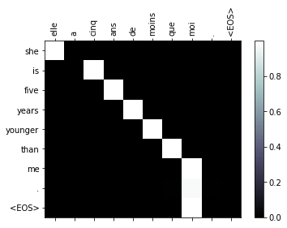

```
input = elle est trop petit .
output = she is too drunk . <EOS>
```

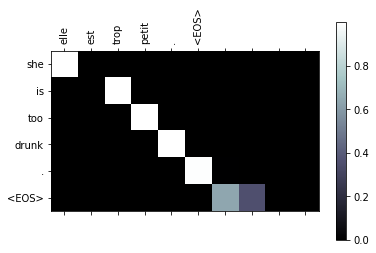

```
input = je ne crains pas de mourir .
output = i m not scared to die . <EOS>
```

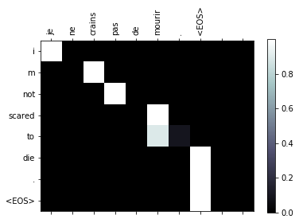

```
input = c est un jeune directeur plein de talent .
output = he s a talented writer . <EOS>
```

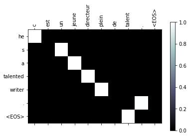

```python
def showAttention(input_sentence, output_words, attentions):
    # Set up figure with colorbar
    fig = plt.figure()
    ax = fig.add_subplot(111)
    cax = ax.matshow(attentions.numpy(), cmap='bone')
    fig.colorbar(cax)

    # Set up axes
    ax.set_xticklabels([''] + input_sentence.split(' ') +
                       ['<EOS>'], rotation=90)
    ax.set_yticklabels([''] + output_words)

    # Show label at every tick
    ax.xaxis.set_major_locator(ticker.MultipleLocator(1))
    ax.yaxis.set_major_locator(ticker.MultipleLocator(1))

    plt.show()


def evaluateAndShowAttention(input_sentence):
    output_words, attentions = evaluate(
        encoder1, attn_decoder1, input_sentence)
    print('input =', input_sentence)
    print('output =', ' '.join(output_words))
    showAttention(input_sentence, output_words, attentions)


evaluateAndShowAttention("elle a cinq ans de moins que moi .")

evaluateAndShowAttention("elle est trop petit .")

evaluateAndShowAttention("je ne crains pas de mourir .")

evaluateAndShowAttention("c est un jeune directeur plein de talent .")
```

|  | このチュートリアルではアテンションの可視化もしているね（以下）。…これをみると、not を読みだすときに注目しているのは ne/pas の両方じゃなくて pas だけだなあ…。形容詞の前置修飾と後置修飾はどうだろう。 |
| --- | --- |

```
input = c est un employe de bureau .
output = he is an office worker . <EOS>
```

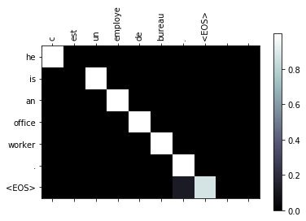

```python
evaluateAndShowAttention("c est un employe de bureau .")
```

|  | これでもアテンションの重みが大きいマスは概ね対角線上に並んでいるなあ…。アテンションは意味の対応する語に注目するわけではないのか、今回が訓練データに過学習なのかなあ…。 |
| --- | --- |
|  | ええ…。 |
|  | チュートリアルの最後には Exercises として、別の言語間の翻訳機にしてみようとか、会話応答などを学んでみようとか、学習済みの単語埋め込みをつかってみようとか、層数を変えてみようとか、入出力を同一にしてオートエンコーダを学習した後デコーダだけ新しく学習しようとかあるね。最後のはどう変わるんだろう？ |

おわり